# IPG Analysis

# Summary Statistics

In 2019-2020 there were 245 observations, while in 2020-2021 there were 14 observations from the IPG forms. Looking at this by school, we can also see that there are very few sites with more than 50 observations, or schools with over 5 observations. The distributions of schools and sites match as we would expect.

# Counts of Different Sites

| Name of Site (Parish, District, Network) | n |
| --- | --- |
| Lafayette Parish | 111 |
| Building 21 | 37 |
| District 11 Curriculum Audit | 34 |
| D11 NYC Robin Hood | 32 |
| Freire Charter Schools | 16 |
| Springfield Empowerment Zone | 10 |
| Legacy | 8 |
| District 11 | 7 |
| East Baton Rouge Parish | 4 |
| Legacy Early College | 3 |

[output cut: 5 more lines]

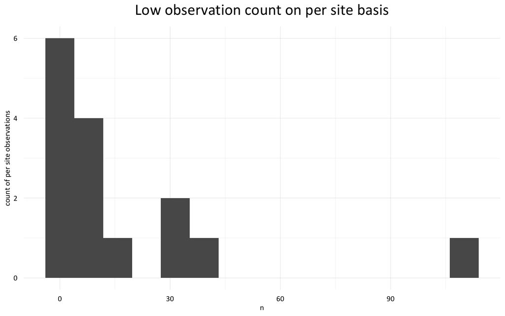

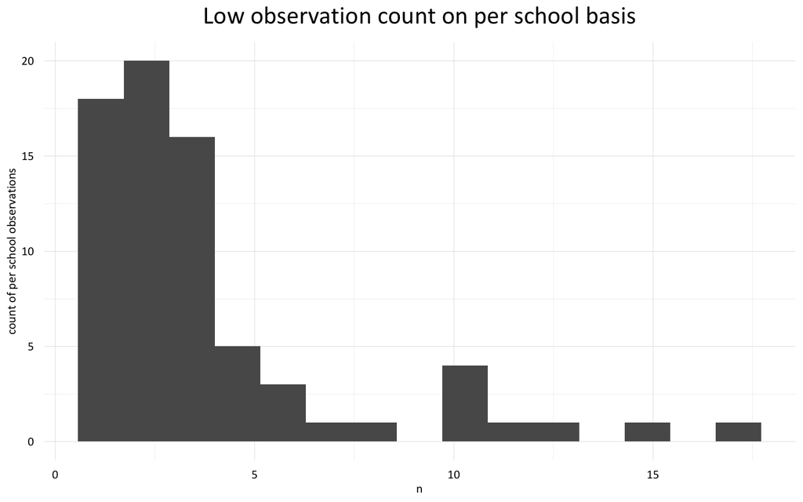

Looking at the different rubrics we see a lot more ELA observations than Mathematics observations, and a lot more K-12 observations as well.

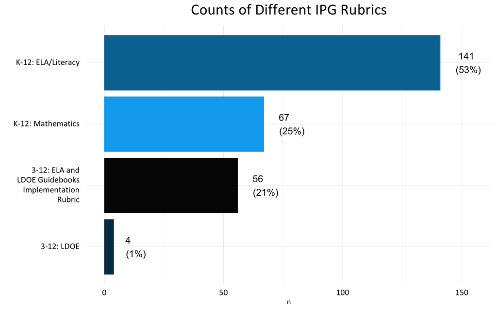

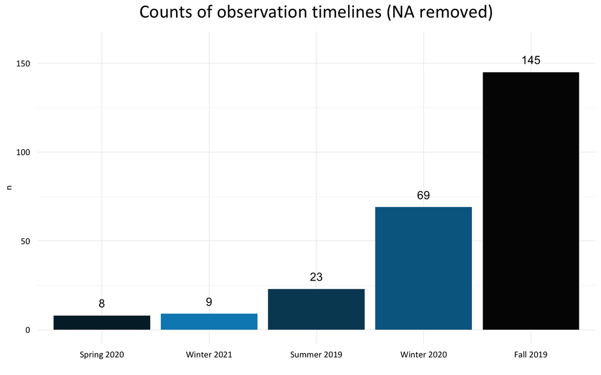

# Grading the data

## Literary/Informational Data

In the following table the percentage of each question that has the answers shown in the answer column is calculated and displayed with data bars, this is done for the first set of questions that are all for informational or literary types of text.

# Percentage Aligned with Answers

| Question | N | Percent | Answer |
| --- | --- | --- | --- |
| CA1a. A majority of the lesson is spent listening to, reading, writing, or speaking about text(s). | 195 | 0.830769230769231 | ['Yes'] |
| CA1b. The anchor text(s) are at or above the complexity level expected for the grade and time in the school year. | 193 | 0.792746113989637 | ['Yes'] |
| CA1c. The text(s) exhibit exceptional craft and thought and/or provide meaningful information in the service of building knowledge. | 193 | 0.787564766839378 | ['Yes'] |
| CA2a. Questions and tasks address the text by attending to its particular qualitative features: its meaning/purpose and/or language, structure(s), or knowledge demands. | 166 | 0.487951807228916 | ['4- Most questions and tasks attend to the qualitative features of the text to build understanding.\n3- Many questions and tasks attend to the qualitative features of the text to build understanding.… |
| CA2b. Questions and tasks require students to use evidence from the text to demonstrate understanding and to support their ideas about the text. | 173 | 0.508670520231214 | ['4- Most questions and tasks require students to cite evidence from the text.\n3- Many questions and tasks require students to cite evidence from the text.'] |
| CA2c. Questions and tasks attend to the words (academic vocabulary), phrases, and sentences within the text. | 144 | 0.388888888888889 | ['4- Vocabulary questions and tasks consistently focus students on the words, phrases, and sentences that matter most and how they are used in the text.\n3- Vocabulary questions and tasks mostly focus… |
| CA2d. Questions and tasks are sequenced to build knowledge by guiding students to delve deeper into the text and graphics. | 157 | 0.445859872611465 | ['4- Most questions and tasks are intentionally sequenced to support building knowledge.\n3- Some questions and tasks are intentionally sequenced to support building knowledge.'] |
| CA3a. The teacher poses questions and tasks for students to do the majority of the work: speaking/listening, reading, and/or writing; Students do the majority of the work of the lesson | 188 | 0.5 | ['4- Teacher provides many opportunities, and most students take them.\n3- Teacher provides many opportunities, and some students take them; or teacher provides some opportunities and most students ta… |
| CA3b. The teacher cultivates reasoning and meaning making by allowing students to productively struggle; Students persevere through difficulty. | 180 | 0.283333333333333 | ['4- Teacher provides many opportunities, and most students take them.\n3- Teacher provides many opportunities, and some students take them; or teacher provides some opportunities and most students ta… |
| CA3c. The teacher expects evidence and precision from students and probes students’ answers accordingly; Students provide text evidence to support their ideas and display precision in their oral and/o… | 175 | 0.291428571428571 | ['4- Teacher provides many opportunities, and most students take them.\n3- Teacher provides many opportunities, and some students take them; or teacher provides some opportunities and most students ta… |

[output cut: 3 more lines]

Here is the exact same data, but split by year

# Percentage Aligned with Answers by Year

| Question | Percent 2019-2020 | Percent 2020-2021 | N 2019-2020 | N 2020-2021 | Answer |
| --- | --- | --- | --- | --- | --- |
| CA1a. A majority of the lesson is spent listening to, reading, writing, or speaking about text(s). | 0.8125 | 1 | 176 | 10 | Yes |
| CA1b. The anchor text(s) are at or above the complexity level expected for the grade and time in the school year. | 0.784090909090909 | 0.75 | 176 | 8 | Yes |
| CA1c. The text(s) exhibit exceptional craft and thought and/or provide meaningful information in the service of building knowledge. | 0.778409090909091 | 0.75 | 176 | 8 | Yes |
| CA2a. Questions and tasks address the text by attending to its particular qualitative features: its meaning/purpose and/or language, structure(s), or knowledge demands. | 0.483221476510067 | 0.125 | 149 | 8 | 4- Most questions and tasks attend to the qualitative features of the text to build understanding. 3- Many questions and tasks attend to the qualitative features of the text to build understanding. |
| CA2b. Questions and tasks require students to use evidence from the text to demonstrate understanding and to support their ideas about the text. | 0.496774193548387 | 0.222222222222222 | 155 | 9 | 4- Most questions and tasks require students to cite evidence from the text. 3- Many questions and tasks require students to cite evidence from the text. |
| CA2c. Questions and tasks attend to the words (academic vocabulary), phrases, and sentences within the text. | 0.359375 | 0.142857142857143 | 128 | 7 | 4- Vocabulary questions and tasks consistently focus students on the words, phrases, and sentences that matter most and how they are used in the text. 3- Vocabulary questions and tasks mostly focus st… |
| CA2d. Questions and tasks are sequenced to build knowledge by guiding students to delve deeper into the text and graphics. | 0.425531914893617 | 0.142857142857143 | 141 | 7 | 4- Most questions and tasks are intentionally sequenced to support building knowledge. 3- Some questions and tasks are intentionally sequenced to support building knowledge. |
| CA3a. The teacher poses questions and tasks for students to do the majority of the work: speaking/listening, reading, and/or writing; Students do the majority of the work of the lesson | 0.497076023391813 | 0.125 | 171 | 8 | 4- Teacher provides many opportunities, and most students take them. 3- Teacher provides many opportunities, and some students take them; or teacher provides some opportunities and most students take … |
| CA3b. The teacher cultivates reasoning and meaning making by allowing students to productively struggle; Students persevere through difficulty. | 0.26219512195122 | 0 | 164 | 7 | 4- Teacher provides many opportunities, and most students take them. 3- Teacher provides many opportunities, and some students take them; or teacher provides some opportunities and most students take … |
| CA3c. The teacher expects evidence and precision from students and probes students’ answers accordingly; Students provide text evidence to support their ideas and display precision in their oral and/o… | 0.272151898734177 | 0.125 | 158 | 8 | 4- Teacher provides many opportunities, and most students take them. 3- Teacher provides many opportunities, and some students take them; or teacher provides some opportunities and most students take … |

[output cut: 3 more lines]

Now I know there may be some doubt about whether the 2020-2021 data is actually like that so see the following table of solely 2020-2021 data - which is the entirety of that data:

| CA1a. A majority of the lesson is spent listening to, reading, writing, or speaking about text(s). | CA1b. The anchor text(s) are at or above the complexity level expected for the grade and time in the school year. | CA1c. The text(s) exhibit exceptional craft and thought and/or provide meaningful information in the service of building knowledge. | CA2a. Questions and tasks address the text by attending to its particular qualitative features: its meaning/purpose and/or language, structure(s), or knowledge demands. | CA2b. Questions and tasks require students to use evidence from the text to demonstrate understanding and to support their ideas about the text. | CA2c. Questions and tasks attend to the words (academic vocabulary), phrases, and sentences within the text. | CA2d. Questions and tasks are sequenced to build knowledge by guiding students to delve deeper into the text and graphics. | CA3a. The teacher poses questions and tasks for students to do the majority of the work: speaking/listening, reading, and/or writing; Students do the majority of the work of the lesson | CA3b. The teacher cultivates reasoning and meaning making by allowing students to productively struggle; Students persevere through difficulty. | CA3c. The teacher expects evidence and precision from students and probes students’ answers accordingly; Students provide text evidence to support their ideas and display precision in their oral and/o… | CA3d. The teacher creates the conditions for student conversations where students are encouraged to talk about each other’s thinking; Students talk and ask questions about each other’s thinking, in or… | CA3e. The teacher deliberately checks for understanding throughout the lesson and adapts the lesson according to student understanding; When appropriate, students refine written and/or oral responses. | CA3f. When appropriate, the teacher explicitly attends to strengthening students’ language and reading foundational skills; Students demonstrate use of language conventions and decoding skills, activa… |
| --- | --- | --- | --- | --- | --- | --- | --- | --- | --- | --- | --- | --- |
| Yes | No | No | 1- Questions and tasks do not attend to the qualitative features of the text to build understanding. | 1- Questions and tasks can be answered without evidence from the text. | 1- No questions and tasks focus students on the words that matter most and how they are used in the text. | 1- Questions and tasks seem random and are not intentionally sequenced to support building knowledge.building knowledge. | 1- Teacher provides few or no opportunities, or few or very few students take the opportunities provided. | 1- Teacher provides few or no opportunities, or few or very few students take the opportunities provided. | 1- Teacher provides few or no opportunities, or few or very few students take the opportunities provided. | 1- Teacher provides few or no opportunities, or few or very few students take the opportunities provided. | 1- Teacher provides few or no opportunities, or few or very few students take the opportunities provided. | Not observed |
| Yes | Yes | Yes | 1- Questions and tasks do not attend to the qualitative features of the text to build understanding. | 1- Questions and tasks can be answered without evidence from the text. | 1- No questions and tasks focus students on the words that matter most and how they are used in the text. | 1- Questions and tasks seem random and are not intentionally sequenced to support building knowledge.building knowledge. | 1- Teacher provides few or no opportunities, or few or very few students take the opportunities provided. | 1- Teacher provides few or no opportunities, or few or very few students take the opportunities provided. | 1- Teacher provides few or no opportunities, or few or very few students take the opportunities provided. | 1- Teacher provides few or no opportunities, or few or very few students take the opportunities provided. | 1- Teacher provides few or no opportunities, or few or very few students take the opportunities provided. | Not observed |
| Yes | Yes | Yes | Not observed | Not observed | Not observed | Not observed | Not observed | Not observed | Not observed | Not observed | Not observed | Not observed |
| Yes | Yes | Yes | 4 | 3 | 4 | 4 | 3 | 2- Teacher provides some opportunities, and some students take them. | 2- Teacher provides some opportunities, and some students take them. | 2- Teacher provides some opportunities, and some students take them. | 1- Teacher provides few or no opportunities, or few or very few students take the opportunities provided. | 1- Teacher provides few or no opportunities, or few or very few students take the opportunities provided. |
| Yes | No | No | 1- Questions and tasks do not attend to the qualitative features of the text to build understanding. | 1- Questions and tasks can be answered without evidence from the text. | 1- No questions and tasks focus students on the words that matter most and how they are used in the text. | 1- Questions and tasks seem random and are not intentionally sequenced to support building knowledge.building knowledge. | 1- Teacher provides few or no opportunities, or few or very few students take the opportunities provided. | 1- Teacher provides few or no opportunities, or few or very few students take the opportunities provided. | 1- Teacher provides few or no opportunities, or few or very few students take the opportunities provided. | 1- Teacher provides few or no opportunities, or few or very few students take the opportunities provided. | 2- Teacher provides some opportunities, and some students take them. | Not observed |
| Yes | Yes | Yes | 2- Few questions and tasks attend to the qualitative features of the text to build understanding. | 2- Few questions and tasks require students to cite evidence from the text. | 1- No questions and tasks focus students on the words that matter most and how they are used in the text. | 2- Few questions and tasks are intentionally sequenced to support building knowledge. | 1- Teacher provides few or no opportunities, or few or very few students take the opportunities provided. | 1- Teacher provides few or no opportunities, or few or very few students take the opportunities provided. | 1- Teacher provides few or no opportunities, or few or very few students take the opportunities provided. | 1- Teacher provides few or no opportunities, or few or very few students take the opportunities provided. | 1- Teacher provides few or no opportunities, or few or very few students take the opportunities provided. | Not observed |
| Yes | Yes | Yes | 2- Few questions and tasks attend to the qualitative features of the text to build understanding. | 3 | 1- No questions and tasks focus students on the words that matter most and how they are used in the text. | 2- Few questions and tasks are intentionally sequenced to support building knowledge. | 2- Teacher provides some opportunities, and some students take them. | 2- Teacher provides some opportunities, and some students take them. | 3 | 1- Teacher provides few or no opportunities, or few or very few students take the opportunities provided. | 1- Teacher provides few or no opportunities, or few or very few students take the opportunities provided. | Not observed |
| Yes | Yes | Yes | 2- Few questions and tasks attend to the qualitative features of the text to build understanding. | 2- Few questions and tasks require students to cite evidence from the text. | 1- No questions and tasks focus students on the words that matter most and how they are used in the text. | 2- Few questions and tasks are intentionally sequenced to support building knowledge. | 2- Teacher provides some opportunities, and some students take them. | 1- Teacher provides few or no opportunities, or few or very few students take the opportunities provided. | 1- Teacher provides few or no opportunities, or few or very few students take the opportunities provided. | 2- Teacher provides some opportunities, and some students take them. | 1- Teacher provides few or no opportunities, or few or very few students take the opportunities provided. | Not observed |
| NA | NA | NA | NULL | NULL | NULL | NULL | NULL | NULL | NULL | NULL | NULL | NA |
| NA | NA | NA | NULL | NULL | NULL | NULL | NULL | NULL | NULL | NULL | NULL | NA |
| NA | NA | NA | NULL | NULL | NULL | NULL | NULL | NULL | NULL | NULL | NULL | NA |
| NA | NA | NA | NULL | NULL | NULL | NULL | NULL | NULL | NULL | NULL | NULL | NA |
| Yes | NA | NA | 1- Questions and tasks do not attend to the qualitative features of the text to build understanding. | 2- Few questions and tasks require students to cite evidence from the text. | NULL | NULL | 2- Teacher provides some opportunities, and some students take them. | NULL | NULL | NULL | NULL | NA |
| Yes | NA | NA | NULL | 2- Few questions and tasks require students to cite evidence from the text. | NULL | NULL | NULL | NULL | 2- Teacher provides some opportunities, and some students take them. | NULL | NULL | NA |

### LDOE Data

LDOE Question data is looked at here briefly just to see the percent that said yes vs. no (as well as not observed). There was no data at all in 2020-2021 so no data is presented for the year split.

# Percentage Aligned with Answers

| Question | Percent | N | Answer |
| --- | --- | --- | --- |
| LDOE 1B: Teachers use the Tier 1 curriculum as intended. During the walkthroughs, use a smartphone or tablet to pull up the teacher version of the lesson. Is the teacher following the detailed teacher… | 0.925 | 40 | Yes |
| LDOE 1C: Are students consistently engaging with grade-level texts to the level demanded by the Tier 1 curriculum. Flip through a student's notebook or binder to see that students have been responding… | 0.875 | 40 | Yes |
| LDOE 3F: Students respond to texts they read in a variety of ways and groupings. Do students write, discuss in groups, and discuss whole-class to answer questions about the text they read? | 0.527777777777778 | 36 | Yes |
| LDOE 3g: The teacher uses prompts and questions to push students to share their thinking. For example, "Tell me more..." "How do you know...?" "Who can add to what X said about the text...?" | 0.526315789473684 | 38 | Yes |

## Math Data

Finally looking at the math data we replicate the tables above

# Percentage Aligned with Answers

| Question | N | Percent | Answer |
| --- | --- | --- | --- |
| CA1a. The enacted lesson focuses on the grade-level cluster(s), grade-level content standard(s), or part(s) thereof. | 65 | 0.738461538461539 | ['Yes'] |
| CA1b. The enacted lesson appropriately relates new content to math content within or across grades. | 61 | 0.786885245901639 | ['Yes'] |
| CA1c. The enacted lesson intentionally targets the aspect(s) of Rigor (conceptual understanding, procedural skill and fluency, application) called for by the standard(s) being addressed. | 63 | 0.444444444444444 | ['Yes'] |
| CA2a. The teacher makes the mathematics of the lesson explicit through the use of explanations, representations, tasks, and/or examples. | 52 | 0.346153846153846 | ['4- A variety of instructional techniques and examples are used to make the mathematics of the lesson clear. 3- Examples are used to make the mathematics of the lesson clear.'] |
| CA2b. The teacher strengthens all students’ understanding of the content by strategically sharing students’ representations and/or solution methods. | 50 | 0.2 | ['3- Student solution methods are shared, and some mathematical connections are made between them.'] |
| CA2c. The teacher deliberately checks for understanding throughout the lesson to surface misconceptions and opportunities for growth, and adapts the lesson according to student understanding. | 54 | 0.259259259259259 | ['3- There are checks for understanding used throughout the lesson to assess progress of some students; minimal adjustments are made to instruction, even when adjustments are appropriate.'] |
| CA2d. The teacher facilitates the summary of the mathematics with references to student work and discussion in order to reinforce the purpose of the lesson. | 36 | 0.166666666666667 | ['3- The lesson includes a summary with a focus on the mathematics.'] |
| CA3a. The teacher provides opportunities for all students to work with and practice grade-level (or course-level) problems and exercises; Students work with and practice grade-level (or course-level) … | 56 | 0.375 | ['4- Teacher provides many opportunities, and most students take them. Teacher provides many opportunities, and some students take them; or teacher provides some opportunities and most students take t… |
| CA3b. The teacher cultivates reasoning and problem solving by allowing students to productively struggle; Students persevere in solving problems in the face of difficulty. | 54 | 0.240740740740741 | ['4- Teacher provides many opportunities, and most students take them. 3- Teacher provides many opportunities and some students take them; or teacher provides some opportunities and most students take… |
| CA3c. The teacher poses questions and problems that prompt students to explain their thinking about the content of the lesson; Students share their thinking about the content of the lesson beyond just… | 57 | 0.298245614035088 | ['4- Teacher provides many opportunities, and most students take them. 3- Teacher provides many opportunities and some students take them; or teacher provides some opportunities and most students take… |

[output cut: 2 more lines]

Once again the above table is replicated for its yearly numbers

# Percentage Aligned with Answers by Year

| Question | Percent 2019-2020 | Percent 2020-2021 | N 2019-2020 | N 2020-2021 | Answer |
| --- | --- | --- | --- | --- | --- |
| CA1a. The enacted lesson focuses on the grade-level cluster(s), grade-level content standard(s), or part(s) thereof. | 0.725806451612903 | 1 | 62 | 3 | Yes |
| CA1b. The enacted lesson appropriately relates new content to math content within or across grades. | 0.775862068965517 | 1 | 58 | 3 | Yes |
| CA1c. The enacted lesson intentionally targets the aspect(s) of Rigor (conceptual understanding, procedural skill and fluency, application) called for by the standard(s) being addressed. | 0.433333333333333 | 0.666666666666667 | 60 | 3 | Yes |
| CA2a. The teacher makes the mathematics of the lesson explicit through the use of explanations, representations, tasks, and/or examples. | 0.346938775510204 | 0.333333333333333 | 49 | 3 | 4- A variety of instructional techniques and examples are used to make the mathematics of the lesson clear. 3- Examples are used to make the mathematics of the lesson clear. |
| CA2b. The teacher strengthens all students’ understanding of the content by strategically sharing students’ representations and/or solution methods. | 0.212765957446809 | 0 | 47 | 3 | 3- Student solution methods are shared, and some mathematical connections are made between them. |
| CA2c. The teacher deliberately checks for understanding throughout the lesson to surface misconceptions and opportunities for growth, and adapts the lesson according to student understanding. | 0.274509803921569 | 0 | 51 | 3 | 3- There are checks for understanding used throughout the lesson to assess progress of some students; minimal adjustments are made to instruction, even when adjustments are appropriate. |
| CA2d. The teacher facilitates the summary of the mathematics with references to student work and discussion in order to reinforce the purpose of the lesson. | 0.181818181818182 | 0 | 33 | 3 | 3- The lesson includes a summary with a focus on the mathematics. |
| CA3a. The teacher provides opportunities for all students to work with and practice grade-level (or course-level) problems and exercises; Students work with and practice grade-level (or course-level) … | 0.358490566037736 | 0.666666666666667 | 53 | 3 | 4- Teacher provides many opportunities, and most students take them. Teacher provides many opportunities, and some students take them; or teacher provides some opportunities and most students take the… |
| CA3b. The teacher cultivates reasoning and problem solving by allowing students to productively struggle; Students persevere in solving problems in the face of difficulty. | 0.235294117647059 | 0.333333333333333 | 51 | 3 | 4- Teacher provides many opportunities, and most students take them. 3- Teacher provides many opportunities and some students take them; or teacher provides some opportunities and most students take t… |
| CA3c. The teacher poses questions and problems that prompt students to explain their thinking about the content of the lesson; Students share their thinking about the content of the lesson beyond just… | 0.314814814814815 | 0 | 54 | 3 | 4- Teacher provides many opportunities, and most students take them. 3- Teacher provides many opportunities and some students take them; or teacher provides some opportunities and most students take t… |

[output cut: 2 more lines]